# S1.4e: i nuclei simulati si toccano troppo perché li disegniamo rotondi?

geo_spatialtrans, report di step (protocollo v2)

Published

October 28, 2026

# In breve

## In breve: i nuclei simulati si toccano troppo perché li disegniamo rotondi?

**A cosa serviva.** Negli ultimi step i nuclei simulati del tumore del colon, dello stroma del tumore e del linfonodo si toccavano più di quelli veri, anche a parità di distanza fra i centri, e spostare o togliere cellule non cambiava le cose. Oggi il simulatore disegna ogni nucleo come un disco, ritagliato dentro il territorio della sua cellula e riportato all’area giusta. Qui lo abbiamo disegnato anche come un’ellisse allungata quanto i nuclei veri, orientata a caso oppure lungo l’asse lungo del territorio, e abbiamo confrontato i tre disegni con i tuoi giudizi di contatto: sulle 300 simulazioni dei preset e mettendo i nuclei sui tuoi stessi punti.

**Cosa abbiamo trovato**

1. **L’ellisse orientata lungo il territorio toglie circa un contatto su dieci nei quattro tessuti densi e non peggiora nessun tessuto, ma secondo la regola fissata prima del calcolo il disco resta.**
   - Nuclei con almeno un vicino a contatto, dal disco all’ellisse orientata: intestino 0.57 → 0.47; tumore del colon 0.69 → 0.59 (vero al più 0.57); stroma 0.36 → 0.28 (al più 0.28); linfonodo 0.83 → 0.73 (al più 0.75). Nei tre tessuti che erano fuori dal vero si passa ad «al limite».
   - L’ellisse riproduce 4 misure su 10, il disco 3; la regola chiedeva almeno 2 in più. Il margine è sottile: nel linfonodo l’ellisse manca la conferma per pochissimo.
2. **Conta l’orientamento, non l’allungamento.** L’ellisse orientata a caso dà gli stessi contatti del disco (al più 0.02 in più). Sui tuoi stessi punti, sotto i 6 µm, l’ellisse orientata toglie da 6 a 15 coppie a contatto su 100; quella a caso quasi nessuna, un poco solo nello stroma.
3. **Ma l’ellisse orientata esagera l’allineamento.** Fra i nuclei allungati con il vicino a meno di 5 µm, quelli messi di traverso al vicino sono 77-87 su 100 nei tessuti veri, 86-94 con l’ellisse orientata, 61-75 con quella a caso. I nuclei veri stanno circa a metà strada fra il caso e l’allineamento perfetto.
4. **Nell’intestino il disegno nuovo basta; nel tumore del colon e nello stroma resta un eccesso grande che il disegno del nucleo non spiega, e lì il riferimento manuale è il meno sicuro.**
   - Sui tuoi punti, coppie a contatto sotto i 6 µm con l’ellisse orientata: intestino 0.33 contro il tuo 0.35; tumore del colon 0.72 contro 0.30; stroma 0.74 contro 0.47.
   - Nel tumore, sulle stesse coppie vicine, anche le maschere di Cellpose si toccano 5 volte su 6 contro le tue 2 su 6, e Federica vede contatti in 44 coppie su 100 contro le tue 17 (su una decina di coppie). Negli altri tessuti densi i vostri giudizi sono vicini.
5. **L’imprecisione dei punti manuali, circa un micron, spiega solo una parte dell’eccesso a parità di distanza.** Spostando i centri simulati di un errore come quello dei tuoi punti, il disco resta fuori dal vero nel tumore del colon e nel linfonodo.

**Cosa devi decidere**

1. **Lasciamo il disco nei preset e proviamo un orientamento parziale, a metà fra il caso e l’asse del territorio? Consiglio di sì.**
   - È quello che dice la regola fissata prima del calcolo, e l’ellisse orientata cambierebbe un difetto (troppi contatti) con un altro (nuclei troppo allineati).
   - Un orientamento lungo il territorio con una dispersione tarata sull’allineamento vero dovrebbe dare contatti fra i due disegni provati oggi, e lo si può giudicare sulle stesse misure.
   - Alternativa: adottare subito l’ellisse orientata. I contatti sarebbero più vicini al vero in quattro tessuti, ma i nuclei troppo allineati; cambierebbe i nuclei di ogni simulazione e i controlli bit per bit con gli step precedenti, quindi lo faremmo quando consolideremo il codice dello Step 1.
2. **Chiediamo a Federica di giudicare le coppie del tumore del colon e dello stroma che non ha visto? Consiglio di sì.**
   - Sono circa 320 coppie in 4 finestre (233 di tumore, 87 di stroma). L’annotatore ha registrato circa un secondo per coppia, pause escluse.
   - Con due giudizi su tutte le finestre sapremo se nel tumore il riferimento è troppo basso, prima di spingere ancora il disegno del nucleo.
   - Alternativa: tenere il tuo giudizio da solo. Allora nel tumore continueremo a inseguire un valore che potrebbe essere troppo basso, e una parte dell’eccesso resterà senza spiegazione.

**Comunque**

- I preset non cambiano; le ellissi orientate a caso o lungo il territorio restano nel pacchetto come opzioni, come prima.
- Quando riprenderemo il disegno del nucleo proveremo l’orientamento parziale.
- Quando consolideremo il codice toglieremo i frammenti di area nulla che il ritaglio lascia attaccati a molti nuclei: oggi non cambiano nessuna misura.

Appena decidi questi 2 punti, lo step è chiuso.

**Sui tempi di calcolo.** La stima di 1-1,5 ore con 20 processori era mia, ricavata dal tempo per simulazione di S1.5e. Il calcolo è durato circa un quarto d’ora con 20 processori sul server del laboratorio: le 300 simulazioni hanno richiesto 9.6 minuti e le 24 finestre sui tuoi punti 5.8, perché ridisegnare un nucleo costa pochi secondi e qui non servivano le misure lunghe di S1.5e. Test, mutanti e regressioni hanno richiesto circa un’ora in più, su uno o due processori.

# Decisioni e verifiche di Luca

- «vai» (ok sulle previsioni, la regola N e le controprove, dalla chat, 2026-10-28)
- Decisione 1, disco nei preset e orientamento parziale come prossimo tentativo: «ok» (commento al riassunto, 2026-10-28)
- Decisione 2, secondo giudizio di Federica sul tumore del colon e sullo stroma: «mi sembra inutile», quindi non si fa (commento al riassunto, 2026-10-28)
- Decisioni registrate in S1.4e: il disco resta nei preset e il prossimo tentativo sul nucleo è un orientamento parziale; nessun secondo giudizio di Federica sui contatti del tumore del colon e dello stroma (DEC-027). Luca ha letto il riassunto senza sollevare dubbi nuovi: step chiuso.

# Dubbi rinviati

| cosa | perché | cosa serve per chiuderlo | step destinatario | voce di BACKLOG |
| --- | --- | --- | --- | --- |
| contatti ancora in eccesso a parità di distanza nel tumore del colon e nello stroma (sui punti di Luca, sotto 6 µm, ellisse orientata 0.72 e 0.74 contro 0.30 e 0.47) e allineamento esagerato dell’elli… | il disegno del nucleo spiega una parte dell’eccesso (orientamento) ma non tutta; l’orientamento giusto è parziale | orientamento lungo il territorio con dispersione tarata sull’allineamento vero (P-3), giudicato su P-1, P-2 e P-3 come qui | modello del nucleo, parte 2 (da assegnare) | BL-171 |
| riferimento manuale dei contatti nel tumore del colon (Luca 0.17 contro Federica 0.44 sulle stesse coppie vicine; maschere Cellpose 5/6 contro 2/6) | l’eccesso residuo più grande sta dove il riferimento è meno sicuro | **deciso da Luca** (2026-10-28, «mi sembra inutile»): nessun secondo giudizio, il riferimento resta il suo; il limite resta dichiarato (DEC-027) | nessuno (chiuso) | BL-172 |
| frammenti di area ≤ 1e-9 µm² attaccati ai nuclei ritagliati (nel cervello al 90 %) | non cambiano raster né contatti, ma fanno di molti nuclei dei poligoni in più parti | togliere le parti degeneri dopo il ritaglio e rigenerare i controlli bit per bit | S1.6 (consolidamento) | BL-173 |
| centri doppi al bordo delle finestre nel banco A (punto di Luca e centro del segmentatore entro 2 µm appena fuori dalla finestra) | ereditato da R3b; nessuna coppia giudicata coinvolta | togliere i centri del segmentatore entro circa 1 µm da un punto di Luca e ripetere CP-1 come sensibilità | da assegnare (con BL-171) | BL-174 |

# Cancelli, previsioni e regola

Pre-registrazione: cancelli al commit `250b31d`; ok di Luca il 2026-10-28 («vai», commit `932f883`). Codice e test al commit `174f08e`; risultati prima della revisione `9a198a8`; correzioni della revisione `9c30d16`.

Bracci: **K2** il disco di oggi, ritagliato nel territorio e riportato all’area giusta; **ER** ellisse con l’eccentricità vera del tessuto, orientata a caso; **ET** la stessa ellisse lungo l’asse maggiore del territorio. Stessi centri, territori, semi e aree bersaglio.

Previsioni: stima ± 2 errori standard ed esito per braccio (P-1, P-2: seme; P-3, P-4: ROI; P-3 di K2 descrittiva)

| id | tessuto | intervallo | K2 | ER | ET |
| --- | --- | --- | --- | --- | --- |
| P-1 | intestino di topo | 0.366-0.650 | 0.569 ± 0.024 confermata | 0.578 ± 0.030 confermata | 0.472 ± 0.023 confermata |
| P-1 | tumore del colon | 0.217-0.567 | 0.686 ± 0.044 smentita | 0.694 ± 0.043 smentita | 0.594 ± 0.030 indeterminata |
| P-1 | stroma del tumore | 0.083-0.283 | 0.360 ± 0.051 smentita | 0.379 ± 0.056 smentita | 0.279 ± 0.050 indeterminata |
| P-1 | linfonodo | 0.350-0.750 | 0.833 ± 0.019 smentita | 0.839 ± 0.015 smentita | 0.735 ± 0.019 indeterminata |
| P-1 | cervello di topo | 0.000-0.217 | 0.144 ± 0.016 confermata | 0.138 ± 0.018 confermata | 0.113 ± 0.017 confermata |
| P-1 | cuore | 0.000-0.070 | 0.070 ± 0.025 indeterminata | 0.080 ± 0.024 indeterminata | 0.057 ± 0.020 indeterminata |
| P-2 | intestino di topo | 0.235-0.481 | 0.521 ± 0.023 smentita | 0.534 ± 0.024 smentita | 0.418 ± 0.020 confermata |
| P-2 | tumore del colon | 0.083-0.515 | 0.865 ± 0.021 smentita | 0.849 ± 0.027 smentita | 0.743 ± 0.033 smentita |
| P-2 | stroma del tumore | 0.188-0.900 | 0.853 ± 0.041 confermata | 0.856 ± 0.031 confermata | 0.690 ± 0.060 confermata |
| P-2 | linfonodo | 0.139-0.451 | 0.549 ± 0.022 smentita | 0.553 ± 0.023 smentita | 0.450 ± 0.019 indeterminata |
| P-3 | intestino di topo | 0.757-0.776 | 0.995 ± 0.001 descrittiva | 0.613 ± 0.002 smentita | 0.860 ± 0.002 smentita |
| P-3 | tumore del colon | 0.834-0.893 | 0.995 ± 0.002 descrittiva | 0.743 ± 0.003 smentita | 0.921 ± 0.005 smentita |
| P-3 | stroma del tumore | 0.819-0.879 | 0.999 ± 0.001 descrittiva | 0.753 ± 0.009 smentita | 0.941 ± 0.004 smentita |
| P-3 | linfonodo | 0.752-0.786 | 0.999 ± 0.001 descrittiva | 0.643 ± 0.001 smentita | 0.890 ± 0.001 smentita |
| P-3 | cuore | 0.741-0.857 | 1.000 ± 0.000 descrittiva | 0.670 ± 0.019 smentita | 0.915 ± 0.020 smentita |
| P-4 | intestino di topo | 0.787-0.817 | 0.001 ± 0.000 smentita | 0.800 ± 0.000 confermata | 0.800 ± 0.000 confermata |
| P-4 | tumore del colon | 0.746-0.805 | 0.277 ± 0.016 smentita | 0.777 ± 0.001 confermata | 0.780 ± 0.000 confermata |
| P-4 | stroma del tumore | 0.761-0.871 | 0.000 ± 0.000 smentita | 0.810 ± 0.000 confermata | 0.810 ± 0.000 confermata |
| P-4 | linfonodo | 0.591-0.608 | 0.001 ± 0.000 smentita | 0.600 ± 0.000 confermata | 0.600 ± 0.000 confermata |
| P-4 | cervello di topo | 0.541-0.628 | 0.000 ± 0.000 smentita | 0.560 ± 0.000 confermata | 0.560 ± 0.000 confermata |
| P-4 | cuore | 0.771-0.866 | 0.000 ± 0.000 smentita | 0.810 ± 0.000 confermata | 0.810 ± 0.000 confermata |

Regola N: conferme in P-1 e P-2 per braccio; condizioni (a) almeno K2 + 2, (b) nessun tessuto confermato da K2 in P-1 diventa smentito

| arm | score_P1_P2 | P3_confirmed | cond_a | cond_b | winner | why |
| --- | --- | --- | --- | --- | --- | --- |
| K2 | 3 | 0 | True | True | K2 | nessuna ellisse supera K2 di almeno 2 voci senza peggiorare un tessuto confermato |
| ER | 3 | 0 | False | True | K2 | nessuna ellisse supera K2 di almeno 2 voci senza peggiorare un tessuto confermato |
| ET | 4 | 0 | False | True | K2 | nessuna ellisse supera K2 di almeno 2 voci senza peggiorare un tessuto confermato |

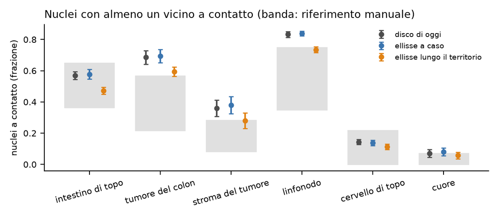

Nuclei con almeno un vicino a contatto nelle finestre contate a mano, per tessuto e braccio (stima ± 2 errori standard, 10 semi). Banda grigia: riferimento manuale (B-127…B-132).

Cosa guardare: nei quattro tessuti densi l’ellisse lungo il territorio (arancione) scende di circa un decimo e porta tumore del colon, stroma e linfonodo al bordo della banda; l’ellisse a caso (blu) coincide con il disco.

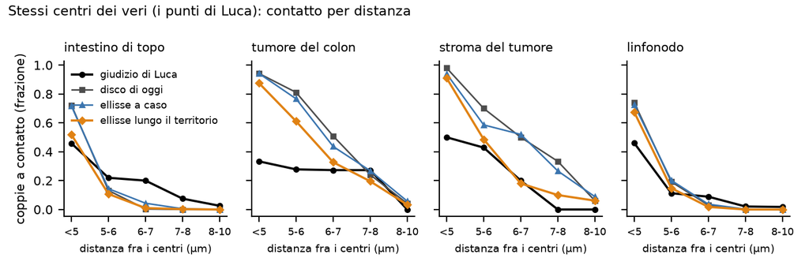

Stessi centri dei veri: i nuclei sono messi sui punti di Luca nelle 4 finestre per tessuto; frazione di coppie giudicate a contatto per classe di distanza fra i centri, giudizio di Luca contro i tre disegni (10 semi).

Cosa guardare: nell’intestino l’ellisse orientata segue il giudizio manuale sotto i 6 µm; nel tumore del colon e nello stroma, a meno di 6 µm, tutti i disegni si toccano molto più del giudizio di Luca.

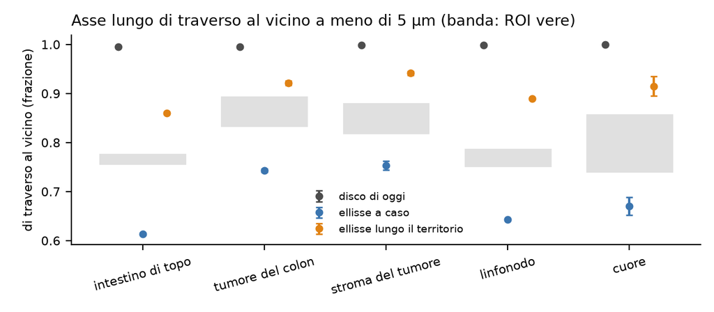

Quota dei nuclei allungati con il vicino a meno di 5 µm che hanno l’asse lungo di traverso al vicino (ROI, stima ± 2 errori standard). Banda: minimo-massimo dei 5 ROI veri.

Cosa guardare: il vero sta fra l’ellisse a caso e l’ellisse orientata, che allinea troppo.

# Dopo il risultato: cancelli, controprove, post hoc e revisione avversariale

Codice e test al commit `174f08e`; banco e risultati prima della revisione al commit `9a198a8`; correzioni della revisione al commit `9c30d16`. Tabelle: `results/S1.4e/S1.4e_verdicts.csv`, `S1.4e_ruleN.csv`, `S1.4e_cp.csv`, `S1.4e_desc.csv`, `S1.4e_PH1_raters.csv`.

### Cancelli

| id | esito | dettaglio |
| --- | --- | --- |
| G-1 | PASS | `test_S1.4e.R` 20/20 (le 18 pre-registrate più T2b, territorio con un buco, e T8 su una finestra del cuore con 11 esclusioni, aggiunte dopo la revisione); `S1.4e_pairs_test.py` 11/11 (5 più T5b, T9, T… |
| G-2 | PASS | 6/6 pre-registrati; 13/13 con M7-M13 aggiunti dopo la revisione (regola dei focali senza esclusioni, coppie con entrambi gli estremi focali, verdetto sbagliato, margine della regola N a 1, origine per… |
| G-3 | PASS | unità RV = RV di S1.5d 300/300 (md5); nuclei K2 ridisegnati = nuclei di `place_cells()` 300/300; banco A, K2 di linfonodo e cuore = CP-1 di R3b 80/80 (WKB); 0 violazioni di contenimento, sovrapposizio… |
| G-4 | PASS | ψ dai poligoni contro `skimage` sul raster: differenza mediana al più 1.08° (limite 2°); eccentricità mediana per unità al più 0.0017 (limite 0.02); contatto di coppia = `n_c2 > 0` per il 100 % dei nu… |
| G-5 | PASS dopo le correzioni | Due revisori indipendenti (sotto). Ricalcolo identico entro 1e-9 di P-1 (18 voci), P-2 (12), P-4 (18), R-1, CP-1 (8 contrasti), CP-2, regola N e identità con S1.5e; P-3 differiva al più di 3.3e-5 per … |

### Previsioni

Stima ± 2 errori standard; esito. P-1 e P-2: seme (10); P-3 e P-4: ROI (5).

| id | tessuto | intervallo | K2 | ER | ET |
| --- | --- | --- | --- | --- | --- |
| P-1 | intestino | 0.366-0.650 | 0.569 ± 0.024 confermata | 0.578 ± 0.030 confermata | 0.472 ± 0.023 confermata |
| P-1 | tumore del colon | 0.217-0.567 | 0.686 ± 0.044 smentita | 0.694 ± 0.043 smentita | 0.594 ± 0.030 indeterminata |
| P-1 | stroma | 0.083-0.283 | 0.360 ± 0.051 smentita | 0.379 ± 0.056 smentita | 0.279 ± 0.050 indeterminata |
| P-1 | linfonodo | 0.350-0.750 | 0.833 ± 0.019 smentita | 0.839 ± 0.015 smentita | 0.735 ± 0.019 indeterminata |
| P-1 | cervello | 0.000-0.217 | 0.144 ± 0.016 confermata | 0.138 ± 0.018 confermata | 0.113 ± 0.017 confermata |
| P-1 | cuore | 0.000-0.070 | 0.070 ± 0.025 indeterminata | 0.080 ± 0.024 indeterminata | 0.057 ± 0.020 indeterminata |
| P-2 | intestino | 0.235-0.481 | 0.521 ± 0.023 smentita | 0.534 ± 0.024 smentita | 0.418 ± 0.020 confermata |
| P-2 | tumore del colon | 0.083-0.515 | 0.865 ± 0.021 smentita | 0.849 ± 0.027 smentita | 0.743 ± 0.033 smentita |
| P-2 | stroma | 0.188-0.900 | 0.853 ± 0.041 confermata | 0.856 ± 0.031 confermata | 0.690 ± 0.060 confermata |
| P-2 | linfonodo | 0.139-0.451 | 0.549 ± 0.022 smentita | 0.553 ± 0.023 smentita | 0.450 ± 0.019 indeterminata |
| P-3 | intestino | 0.757-0.776 | 0.995 (descrittiva) | 0.613 ± 0.002 smentita | 0.860 ± 0.002 smentita |
| P-3 | tumore del colon | 0.834-0.893 | 0.995 (descrittiva) | 0.743 ± 0.003 smentita | 0.921 ± 0.005 smentita |
| P-3 | stroma | 0.819-0.879 | 0.999 (descrittiva) | 0.753 ± 0.009 smentita | 0.941 ± 0.004 smentita |
| P-3 | linfonodo | 0.752-0.786 | 0.999 (descrittiva) | 0.643 ± 0.001 smentita | 0.890 ± 0.001 smentita |
| P-3 | cuore | 0.741-0.857 | 1.000 (descrittiva) | 0.670 ± 0.019 smentita | 0.915 ± 0.020 smentita |
| P-4 | 6 tessuti | R-3 | 0.000-0.277, smentita 6/6 | = eccentricità d’ingresso, confermata 6/6 | = eccentricità d’ingresso, confermata 6/6 |

Rispetto alle attese.

- **P-1.** Come atteso: ET più bassa di K2 nei quattro tessuti densi di 0.080-0.098 (differenze appaiate per seme, oltre 2 errori standard; attesa almeno 0.04); tumore del colon, stroma e linfonodo indeterminati con ET. ER non più bassa di K2: differenze da +0.006 a +0.020 (stroma al limite dello 0.02). Il cuore, controllo negativo, resta indeterminato in tutti i bracci (0.057-0.080 contro al più 0.070), come previsto.
- **P-2.** K2 smentita in intestino, tumore del colon e linfonodo, come atteso; nello stroma confermata (atteso indeterminata: l’intervallo da 17 coppie arriva a 0.90). ET più bassa in tutti e quattro; il linfonodo è indeterminato invece che smentito, il tumore del colon resta smentito.
- **P-3 smentita per ET in 5 tessuti su 5, contro l’attesa.** ET allinea troppo (0.86-0.94 contro 0.77-0.87 nei ROI veri), ER troppo poco (0.61-0.75). Il vero sta fra il caso e l’allineamento perfetto: (vero − ER) / (ET − ER) = 0.51-0.69 (`S1.4e_desc.csv`). L’orientamento lungo il territorio è giusto nella direzione e troppo forte nella misura. Per K2 i soli nuclei allungati sono i dischi ritagliati, schiacciati contro il vicino: la quota è vicina a 1 ed è descrittiva, come pre-registrato (D-5).
- **P-4.** Come atteso per K2 ed ER/ET (prova debole). La parte «ET più vicina al vero di ER» non è valutabile: le due mediane coincidono con l’eccentricità d’ingresso, perché il nucleo mediano non è ritagliato.

### Regola N

Punteggio (confermate in P-1 e P-2): K2 3, ER 3, ET 4. ET non supera K2 di 2 voci: **resta K2** (`S1.4e_ruleN.csv`), registrato come decisione tecnica S1.4e: nei preset resta il disco ritagliato e riportato all’area giusta; le ellissi orientate a caso o lungo il territorio restano opzioni; CP-1 si giudica sulle coppie giudicate (DEC-026). Il risultato è al margine. Le voci di ET più vicine alla conferma sono il linfonodo in P-1 (estremo alto 0.754 contro 0.750) e in P-2 (0.469 contro 0.451); con una sola di queste confermata, ET arriverebbe a K2 + 2 e la regola la adotterebbe. L’estremo di P-2 resta sopra il limite con 20 semi diversi del bootstrap di R-1 (revisore del codice). Più semi andrebbero decisi prima di guardare il risultato, e non lo si fa in questo step.

### Controprove

- **CP-1, stessi centri: superata.** Coppie giudicate da Luca («non giudicabile» escluse, come R-1 e P-2: D-2) a meno di 6 µm. ET − K2: intestino −0.119 ± 0.018, tumore del colon −0.154 ± 0.044, stroma −0.104 ± 0.077, linfonodo −0.055 ± 0.017, sotto zero in 4/4. ER − K2 non negativa oltre 2 errori standard in 3/4: intestino +0.008, tumore −0.026 ± 0.037, linfonodo +0.000; nello stroma −0.058 ± 0.057, appena sotto zero. Con le coppie «non giudicabile» incluse (come girava il codice prima della revisione) ER − K2 è negativa anche nel tumore (−0.044 ± 0.030) e la parte ER cade a 2/4: l’esito di quella metà dipende da 9 coppie del tumore. In entrambe le letture, nel tumore e nello stroma l’ellisse orientata toglie da due a sei volte i contatti tolti da quella a caso, e nell’intestino e nel linfonodo quella a caso non ne toglie: conta soprattutto l’orientamento, un poco l’allungamento nello stroma.
- **CP-2, rumore dei punti manuali: K2 non rientra.** Con lo spostamento dei centri simulati come l’errore dei punti, K2 in P-2: intestino 0.500 ± 0.020 indeterminata, tumore del colon 0.673 ± 0.020 smentita, stroma 0.621 ± 0.038 confermata, linfonodo 0.528 ± 0.018 smentita. L’eccesso a parità di distanza non è soprattutto un effetto della misura; il rumore però abbassa il contatto simulato sotto i 6 µm da 0.02 (intestino e linfonodo) a 0.23 (stroma), quindi P-2 è sensibile a quanto sono precisi i punti, soprattutto nel tumore e nello stroma. La regola N si giudica su P-1 e P-2 come scritto.

### Post hoc (dichiarato dopo il risultato)

- **PH-1, il riferimento del tumore del colon.** Sulle coppie giudicate da entrambi (2 finestre per tessuto), a meno di 6 µm: tumore del colon Luca 0.167 (12 coppie) contro Federica 0.444 (9); intestino 0.409 contro 0.424; stroma 0.556 contro 0.571; linfonodo 0.188 contro 0.125 (`S1.4e_PH1_raters.csv`). Sulle stesse coppie del tumore le maschere di Cellpose si toccano sotto i 5 µm in 5 casi su 6 contro 2 su 6 per Luca (esplorazione E2). Nel tumore il riferimento manuale è il meno sicuro proprio dove resta l’eccesso più grande; le 233 coppie di tumore e le 87 di stroma che Federica non ha visto sono nelle finestre A2_w1, A2_w3, A3_w2, A3_w4; il tempo mediano per item registrato dall’annotatore è 0.93 s per Luca e 1.04 s per Federica.
- **Stessi centri, coppie giudicate a meno di 6 µm** (`S1.4e_desc.csv`, «banco A < 6 um»): intestino K2 0.451, ET 0.329, Luca 0.348; linfonodo K2 0.418, ET 0.365, Luca 0.256; tumore del colon K2 0.863, ET 0.717, Luca 0.300; stroma K2 0.865, ET 0.735, Luca 0.471. Nell’intestino ET riproduce il giudizio manuale; nel tumore del colon e nello stroma no.

### Correzioni e note

- D-1 (prima della revisione): il conteggio della parte ER di CP-1 usava una negazione su una colonna di tipo misto; corretto prima di leggere il verdetto.
- D-2 (revisione, entrambi i revisori): CP-1 includeva le coppie «non giudicabile»; la pre-registrazione le esclude (numeri di coppie di P-2 e R-1: 89/30/17/121). Corretto; riportate entrambe le letture.
- D-3 (revisione): `poly_shape` usava un’origine per parte nei nuclei in più parti (180-303 nuclei su 2.48 milioni per braccio): centroide sbagliato, P-3 diversa al più di 3.3e-5, nessun verdetto cambiato. Corretto, test T5b e mutante M11.
- D-4: comando di G-4 scritto male nella pre-registrazione; copertura del contatto di coppia più ampia (720 unità invece di 30).
- D-5: P-3 di K2 nel file dei verdetti è etichettata «descrittiva», come pre-registrato.
- Note della revisione senza effetto sui verdetti: P-2 somma le coppie delle 4 finestre per seme (coerente con R-1); con i generatori invece dei centroidi del raster P-2 cambia al più di 0.019; in R2c le coppie con due estremi eleggibili hanno probabilità di inclusione circa doppia (differenza di pesi rispetto a P-2 simulata); il ritaglio lascia frammenti di area ≤ 1e-9 µm² attaccati a molti nuclei (nel cervello al 90 %), senza effetto sul raster (BL-173); nel banco A alcuni punti di Luca hanno un centro del segmentatore entro 2 µm appena fuori dalla finestra, mai in una coppia giudicata (BL-174).

### Revisione avversariale

- Revisore numerico: ricalcolo da zero con codice proprio di P-1…P-4, R-1, CP-1, regola N, identità con S1.5e, raster e coppie a contatto su 6 unità con un rasterizzatore proprio (0 differenze). Rilievi: centroide dei nuclei in più parti (D-3), coppie «non giudicabile» in CP-1 (D-2), regola N al margine, pesi delle coppie di P-2, aggregazione delle finestre.
- Revisore del codice: ridisegno in R di 6 unità (aree bersaglio e tetti identici fra bracci, nuclei riproducibili), convenzioni degli angoli fra R, Python e skimage coerenti, asse del territorio di traverso al vicino nell’82-87 % delle cellule dei tessuti densi, mappa del banco A corretta; 12 mutanti propri, 6 non rilevati dalla batteria di allora (misure e analisi non testate): batteria rafforzata (T2b, T5b, T8 con esclusioni, T9-T11; M7-M13 rilevati). 11 rilievi, uno cambia l’esito di CP-1 (D-2).

Controprove: CP-1 (stessi centri, differenze per finestra; due letture) e CP-2 (P-2 con il rumore dei punti manuali)

| id | archetype | contrast | est | se | lo2 | hi2 | below_zero | n_pairs | verdict | lo | hi | est_no_noise |
| --- | --- | --- | --- | --- | --- | --- | --- | --- | --- | --- | --- | --- |
| CP-1 | A1 | ET-K2 | -0.119 | 0.009 | -0.136 | -0.101 | True | 89 |  | NA | NA | NA |
| CP-1 | A1 | ER-K2 | 0.008 | 0.017 | -0.026 | 0.043 | False | 89 |  | NA | NA | NA |
| CP-1 | A2 | ET-K2 | -0.154 | 0.022 | -0.198 | -0.110 | True | 30 |  | NA | NA | NA |
| CP-1 | A2 | ER-K2 | -0.026 | 0.018 | -0.063 | 0.010 | False | 30 |  | NA | NA | NA |
| CP-1 | A3 | ET-K2 | -0.104 | 0.039 | -0.182 | -0.027 | True | 17 |  | NA | NA | NA |
| CP-1 | A3 | ER-K2 | -0.058 | 0.028 | -0.115 | -0.001 | True | 17 |  | NA | NA | NA |
| CP-1 | A4 | ET-K2 | -0.055 | 0.008 | -0.072 | -0.038 | True | 121 |  | NA | NA | NA |
| CP-1 | A4 | ER-K2 | 0.000 | 0.003 | -0.006 | 0.007 | False | 121 |  | NA | NA | NA |
| CP-1 con le non giudicabili | A1 | ET-K2 | -0.115 | 0.012 | -0.139 | -0.090 | True | 91 |  | NA | NA | NA |
| CP-1 con le non giudicabili | A1 | ER-K2 | 0.011 | 0.018 | -0.025 | 0.046 | False | 91 |  | NA | NA | NA |
| CP-1 con le non giudicabili | A2 | ET-K2 | -0.166 | 0.017 | -0.201 | -0.132 | True | 39 |  | NA | NA | NA |
| CP-1 con le non giudicabili | A2 | ER-K2 | -0.044 | 0.015 | -0.074 | -0.014 | True | 39 |  | NA | NA | NA |
| CP-1 con le non giudicabili | A3 | ET-K2 | -0.104 | 0.039 | -0.182 | -0.027 | True | 17 |  | NA | NA | NA |
| CP-1 con le non giudicabili | A3 | ER-K2 | -0.058 | 0.028 | -0.115 | -0.001 | True | 17 |  | NA | NA | NA |
| CP-1 con le non giudicabili | A4 | ET-K2 | -0.054 | 0.007 | -0.068 | -0.039 | True | 124 |  | NA | NA | NA |
| CP-1 con le non giudicabili | A4 | ER-K2 | -0.002 | 0.002 | -0.007 | 0.002 | False | 124 |  | NA | NA | NA |
| CP-2 | A1 | K2 | 0.500 | 0.010 | 0.481 | 0.520 |  | NA | indeterminata | 0.235 | 0.481 | 0.521 |
| CP-2 | A2 | K2 | 0.673 | 0.010 | 0.654 | 0.693 |  | NA | smentita | 0.083 | 0.515 | 0.865 |
| CP-2 | A3 | K2 | 0.621 | 0.019 | 0.584 | 0.658 |  | NA | confermata | 0.188 | 0.900 | 0.853 |
| CP-2 | A4 | K2 | 0.528 | 0.009 | 0.511 | 0.545 |  | NA | smentita | 0.139 | 0.451 | 0.549 |
| CP-2 | A1 | ET | 0.404 | 0.009 | 0.386 | 0.423 |  | NA | confermata | 0.235 | 0.481 | 0.418 |
| CP-2 | A2 | ET | 0.575 | 0.011 | 0.553 | 0.597 |  | NA | smentita | 0.083 | 0.515 | 0.743 |
| CP-2 | A3 | ET | 0.476 | 0.023 | 0.431 | 0.521 |  | NA | confermata | 0.188 | 0.900 | 0.690 |
| CP-2 | A4 | ET | 0.437 | 0.009 | 0.419 | 0.454 |  | NA | indeterminata | 0.139 | 0.451 | 0.450 |

PH-1: Luca e Federica sulle stesse coppie (classi di distanza fra i punti di Luca)

| what | rater | archetype | cls | n | value |
| --- | --- | --- | --- | --- | --- |
| t_ms mediano per item | Luca |  |  | 1607 | 928.000 |
| t_ms mediano per item | Federica |  |  | 834 | 1035.500 |
| contatto sulle coppie comuni | Luca | A1 | lt6 | 44 | 0.409 |
| contatto sulle coppie comuni | Federica | A1 | lt6 | 33 | 0.424 |
| contatto sulle coppie comuni | Luca | A1 | 6to10 | 92 | 0.065 |
| contatto sulle coppie comuni | Federica | A1 | 6to10 | 89 | 0.045 |
| contatto sulle coppie comuni | Luca | A2 | lt6 | 12 | 0.167 |
| contatto sulle coppie comuni | Federica | A2 | lt6 | 9 | 0.444 |
| contatto sulle coppie comuni | Luca | A2 | 6to10 | 48 | 0.125 |
| contatto sulle coppie comuni | Federica | A2 | 6to10 | 43 | 0.256 |
| contatto sulle coppie comuni | Luca | A3 | lt6 | 9 | 0.556 |
| contatto sulle coppie comuni | Federica | A3 | lt6 | 7 | 0.571 |
| contatto sulle coppie comuni | Luca | A3 | 6to10 | 13 | 0.077 |
| contatto sulle coppie comuni | Federica | A3 | 6to10 | 12 | 0.083 |
| contatto sulle coppie comuni | Luca | A4 | lt6 | 80 | 0.188 |
| contatto sulle coppie comuni | Federica | A4 | lt6 | 72 | 0.125 |
| contatto sulle coppie comuni | Luca | A4 | 6to10 | 98 | 0.010 |
| contatto sulle coppie comuni | Federica | A4 | 6to10 | 97 | 0.010 |
| coppie di Luca in finestre senza Federica | Luca | A2 | A2_w1,A2_w3 | 233 | NA |
| coppie di Luca in finestre senza Federica | Luca | A3 | A3_w2,A3_w4 | 87 | NA |

# Cosa è girato

- Banco B: 300 unità (30 ROI × 10 semi, seme = 20261021 + 1000 · i + s come S1.5d e S1.5e) e 3 ridisegni del nucleo per unità; banco A: 24 finestre × 10 semi × 3 bracci; lesexp-server, 20 worker a un thread (9.6 + 5.8 minuti, catena completa circa un quarto d’ora). Test, mutanti e regressioni circa un’ora, due volte (prima e dopo la revisione).
- md5 dei 310 file letti (dati veri, annotazioni, modelli di taglia di S1.4 e R3b, nuclei della CP-1 di R3b) identici prima e dopo.
- Comandi esatti nella sezione «Riproduzione» del file dello step.

G-3: identità e invarianti

| check | value | expected | pass |
| --- | --- | --- | --- |
| B_units | 300 | 300 | TRUE |
| RV_equals_S1.5d_RV_md5 | 300 | 300 | TRUE |
| K2_redraw_equals_place_cells | 300 | 300 | TRUE |
| A_rows | 720 | 720 | TRUE |
| A_K2_equals_R3b_CP1 | 80 | 80 | TRUE |
| invariant_violations_B | 0 | 0 | TRUE |
| invariant_violations_A | 0 | 0 | TRUE |

G-4: seconda implementazione delle misure

| check | value | limit | pass_ |
| --- | --- | --- | --- |
| psi_median_abs_diff_deg_max_over_units | 1.0791 | 2.00 | True |
| ecc_median_abs_diff_max_over_units | 0.0017 | 0.02 | True |
| pair_contact_vs_nc2_agreement | 1.0000 | 1.00 | True |
| pair_contact_units | 720.0000 | NA | True |

# Appendice

## Dubbi ricevuti

| voce | cosa | perché conta | cosa serve per chiuderla |
| --- | --- | --- | --- |
| BL-166 (da S1.5e, esplorazione E3) | a parità di distanza fra i centri i nuclei simulati si toccano molto più dei veri giudicati a mano: nel tumore del colon, con il vicino a meno di 5 µm, 0.96 contro 0.47; con le distanze manuali il mod… | è la causa dei contatti fuori dal vero in tre tessuti (P-1 di S1.5e smentita nel tumore del colon, nello stroma e nel linfonodo) e togliere cellule non la cambia | misurare il contatto per classe di distanza nel disegno del nucleo (forma, ritaglio, rientro) contro le risposte manuali |

Collegate, non assegnate a questo step ma toccate dai suoi risultati (si aggiornano alla chiusura): BL-142 (linfonodo: contatti simulati nella parte alta del margine), BL-123 (nuclei simulati dischi, veri allungati), BL-063 (allineamento fra nucleo e territorio nei tessuti densi).

## Esplorazione prima della pre-registrazione

Solo dati veri e unità già simulate (S1.5d, braccio RV = la semina dei preset di oggi; R3b, controprova CP-1), nessuna simulazione nuova[^explore]. Le coppie sono quelle giudicate da Luca in R2c (1 319 coppie di tipo «pair»: 1 153 «separate», 118 «touch», 48 «non giudicabile»; conteggi per tessuto in `S1.4e_E12_summary.csv`), la distanza è quella fra i suoi punti di R2b.

**E1. Il contatto manuale cala con la distanza in modo graduale.** Frazione di coppie giudicate «si toccano» («non giudicabile» escluse): intestino < 5 µm 0.46 (48 coppie), 5-6 µm 0.22, 6-7 µm 0.20, 7-8 µm 0.075; linfonodo < 5 µm 0.46 (50), 5-6 µm 0.11, 6-7 µm 0.09; tumore del colon < 5 µm 0.33 (12 coppie giudicate, un terzo «non giudicabile»).

**E2. Le maschere dei segmentatori sulle stesse coppie.** Agganciando i punti di Luca ai nuclei del segmentatore di forma (Cellpose nell’intestino, nel tumore, nello stroma e nel cervello; StarDist nel linfonodo e nel cuore), il contatto della maschera (distanza di Chebyshev ≤ 2 px) sotto i 5 µm vale 0.40 nell’intestino contro 0.42 di Luca sulle stesse coppie; nel tumore del colon 0.83 contro 0.33 (6 coppie). La somma dei raggi dei cerchi di pari area dei due nuclei veri, divisa per la distanza, sotto i 5 µm vale 0.98 nell’intestino e 0.87 nel linfonodo: a quella distanza i nuclei veri sono in media appena tangenti.

**E3. La taglia non è la causa.** Area mediana del nucleo per classe di distanza dal vicino, nuclei veri (punti di Luca agganciati alla maschera) contro simulati (RV, stesse finestre, 10 semi): sotto i 5 µm intestino 14.9 contro 12.4 µm², tumore del colon 29.3 contro 22.1, linfonodo 15.0 contro 15.7. A pari distanza i nuclei simulati non sono più grandi dei veri.

**E4. Sugli stessi centri il nucleo simulato dà un contatto a gradino.** Nel linfonodo, con i punti di Luca come centri (controprova CP-1 di R3b, nucleo di oggi, 10 semi), coppia per coppia: < 5 µm 0.72 simulato contro 0.46 manuale, 5-6 µm 0.18 contro 0.11, 6-7 µm 0.03 contro 0.09. Il simulato passa da quasi sempre a quasi mai in 2 µm; il vero cala più dolcemente.

**E5. I nuclei veri vicini stanno di fianco.** Su tutti i nuclei del segmentatore di forma nei 5 ROI per tessuto: fra i nuclei allungati (rapporto degli assi ≥ 1.2) con il vicino più vicino a meno di 5 µm, quelli con l’asse maggiore di traverso al vicino (angolo > 45°) sono 0.77 nell’intestino, 0.87 nel tumore del colon, 0.86 nello stroma, 0.77 nel linfonodo, 0.80 nel cuore, contro 0.50-0.53 con gli orientamenti permutati fra i nuclei dello stesso ROI; l’effetto si spegne verso i 10 µm (`S1.4e_E5_summary.csv`, intervallo bootstrap dei ROI). Non è solo un artefatto della separazione di due nuclei fusi: resta fra le coppie che Luca ha giudicato separate sotto i 6 µm (quota dei nuclei allungati di quelle coppie: intestino 0.64 su 73 nuclei, tumore 1.00 su 17, stroma 0.90 su 10, linfonodo 0.63 su 71). Il controllo della convenzione dell’angolo (dai pixel della maschera contro la colonna `orientation`) dà differenza mediana 0° su 799 coppie. I nuclei simulati di oggi sono dischi: non hanno orientamento.

**E6. I punti manuali sono rumorosi di circa un micron.** Scarto fra il punto di Luca e il centroide della maschera agganciata, deviazione standard per asse: linfonodo 0.50 µm, intestino 0.67, cuore 0.91, cervello 1.2, tumore del colon 1.25, stroma 1.55 (`S1.4e_E6_click_offset.csv`) (limite superiore: comprende l’errore del segmentatore). Selezionare le coppie per distanza manuale piccola sceglie in parte coppie più lontane di quanto sembri; il simulato, che misura la distanza vera, non lo fa. Lo si tratta nella controprova CP-2.

**Ipotesi dello step.** Il disco ritagliato e riportato all’area giusta raggiunge la faccia in comune ogni volta che la somma dei raggi supera la distanza, e allora tocca il vicino; i nuclei veri allungati, a distanza corta, si mettono di fianco e girano verso il vicino l’asse corto, quindi si toccano meno a pari distanza e area. La si mette alla prova con due ellissi con l’allungamento vero: orientate lungo l’asse maggiore del territorio (che nei tessuti densi è di traverso al vicino più vicino) e orientate a caso (il nullo dell’orientamento).

Non si prova il rientro uniforme del territorio: con l’operatore di contatto a 2 px (0.547 µm) un rientro uniforme è un interruttore (sotto 0.27 µm non cambia i contatti, sopra li toglie tutti); un rientro casuale per cellula sarebbe un parametro libero senza riferimento biologico. Se l’orientamento non basta, lo si scrive e la scelta passa a uno step successivo.

## Pre-registrazione (testo del file dello step)

Commit dei cancelli: `250b31d`. Ok di Luca sulle previsioni, la regola N e le controprove: 2026-10-28, «vai» (in chat, dopo la pagina in linguaggio semplice). Commit: vedi «S1.4e: ok di Luca».

### Bracci

| braccio | nucleo | allungamento (asse maggiore / minore) | orientamento |
| --- | --- | --- | --- |
| K2 | quello di oggi (Come il nucleo ritagliato e riportato all’area giusta è implementato nel pacchetto (DEC-003)): disco ritagliato nel territorio e riportato all’area giusta | 1 | (nessuno) |
| ER | lo stesso modello con un’ellisse | per tessuto, dall’eccentricità mediana vera e: 1/√(1 − e²) = 1.667 / 1.598 / 1.705 / 1.250 / 1.207 / 1.705 (B-115…B-120) | a caso (uniforme) |
| ET | come ER | come ER | asse maggiore del territorio (`nucleus_orient = "territory"`, già nel pacchetto) |

Area bersaglio, tetto φ, modello di taglia, centri e territori identici nei tre bracci: cambia solo la forma. Lo stesso allungamento per tutti i tipi di un tessuto (semplificazione dichiarata).

**Banco B (il simulatore come si usa).** Le 300 unità RV di S1.5d (6 tessuti × 5 ROI × 10 semi, stessi semi): `place_cells()` come in S1.5e, poi i nuclei ridisegnati con `derive_cell_geometry()` sugli stessi centri, territori e catalogo dei tipi, con lo stesso seme dello stadio «size», per K2, ER, ET. Raster con l’operatore unico di S1.4c, finestre e focali come S1.5d/S1.5e.

**Banco A (stessi centri dei veri).** Le 24 finestre di R2b (4 per tessuto) con i punti di Luca come centri dentro la finestra e i centri del segmentatore altrove, come la controprova CP-1 di R3b estesa ai sei tessuti; modello di taglia a un tipo della piega in cui il ROI è di prova (S1.4: Cellpose nell’intestino, nel tumore, nello stroma, nel cervello; R3b: maschera CO nel linfonodo e nel cuore), φ di S1.4d e di R3b; 10 semi; K2, ER, ET.

**Contatto di una coppia** (nuovo, P-2 e CP-1): due nuclei si toccano se un pixel dell’uno è entro distanza di Chebyshev 2 px da un pixel dell’altro sul raster dell’operatore di S1.4c (lo stesso che dà `n_c2`). Coppie simulate: tutte le coppie a distanza fra i centri ≤ d_max del tessuto (R2c) con almeno un estremo focale (regola dei focali di S1.5d), come le coppie giudicate in R2c.

### Cancelli (al massimo 5)

| id | controllo | tolleranza | comando |
| --- | --- | --- | --- |
| G-1 | **batteria di test** `R/testing/test_S1.4e.R` e `tools/S1.4e_pairs_test.py`: (T1) ridisegnare i nuclei di un’unità con i suoi centri, territori, catalogo e seme dà i nuclei di `place_cells()` bit per … | nuovi tutti PASS; regressioni con i soli FAIL noti | `bash R/testing/run_S1.4e.sh test` |
| G-2 | **mutanti** (copie del codice): M1 orientamento ruotato di 90° in ET; M2 allungamento ignorato (= 1) negli override del banco; M3 ridisegno con il seme + 1; M4 ψ con seno e coseno scambiati; M5 contat… | 6/6 rilevati | `bash R/testing/run_S1.4e.sh mutants` |
| G-3 | **identità e invarianti**: unità RV = RV di S1.5d (md5 del livello, 300/300); nuclei K2 ridisegnati = nuclei di `place_cells()` (WKB, 300/300); banco A, K2 nel linfonodo e nel cuore = nuclei della CP-… | 300/300, 300/300, 80/80, 0 violazioni, md5 invariati | `Rscript --vanilla tools/S1.4e_bench.R check` |
| G-4 | **misure nuove con una seconda implementazione**: ψ ed eccentricità dei nuclei simulati dai momenti del poligono contro `skimage.measure.regionprops` sul raster, su 30 unità (una per ROI, ET); contatt… | ψ: differenza mediana ≤ 2°; eccentricità mediana per unità ≤ 0.02; contatto: 100 % dei nuclei | `.venv/bin/python tools/S1.4e_g4.py` |
| G-5 | **ricalcolo indipendente** della revisione avversariale: due revisori ricalcolano dal codice e dai dati P-1…P-4, CP-1, CP-2 e la regola N | identico o ≤ 1e-9 | revisione |

### Previsioni

Unità indipendente per l’incertezza: P-1 e P-2 **seme** (finestre fisse, 10 semi; stima = media dei semi ± 2 errori standard, errore standard = deviazione standard fra semi / √10), come P-1 di S1.5e; P-3 e P-4 **ROI** (valore della ROI = media dei 10 semi; 5 ROI per tessuto, errore standard = deviazione standard fra ROI / √5). Nessun bootstrap sul simulato. Intervalli calcolati prima di ogni simulazione nuova (`S1.4e_refs.csv`[^refs]): R-1 bootstrap a due stadi (finestre, poi coppie), B = 2 000, seme 20261028; R-2 e R-3 = [minimo, massimo] dei 5 ROI veri.

| id | quantità | tessuto | atteso | intervallo di rilevanza | fonte dell’intervallo | 2 errori standard tipici |
| --- | --- | --- | --- | --- | --- | --- |
| P-1 | frazione di nuclei focali con almeno un vicino a contatto, finestre di R2c (banco B) | intestino / tumore del colon / stroma / linfonodo / cervello / cuore | K2 = RV di S1.5e (0.569 / 0.686 / 0.360 / 0.833 / 0.144 / 0.070: confermata, smentita, smentita, smentita, confermata, indeterminata); ET più bassa di K2 di almeno 0.04 nei quattro tessuti densi, con … | 0.366-0.650 / 0.217-0.567 / 0.083-0.283 / 0.350-0.750 / 0.000-0.217 / 0.000-0.070 | B-127…B-132 (come S1.5d, S1.5e) | 0.02-0.05 |
| P-2 | frazione di coppie a contatto con i centri a meno di 6 µm (banco B) | intestino / tumore del colon / stroma / linfonodo | K2 smentita in intestino, tumore del colon e linfonodo, indeterminata nello stroma; ET più bassa di K2 in tutti e quattro, smentita almeno nel linfonodo | 0.235-0.481 / 0.083-0.515 / 0.188-0.900 / 0.139-0.451 | R-1: coppie giudicate da Luca, punti manuali (89 / 30 / 17 / 121 coppie) | 0.01-0.03 |
| P-3 | allineamento: quota dei nuclei allungati (≥ 1.2) con il vicino a meno di 5 µm e asse maggiore di traverso al vicino (> 45°) (banco B) | intestino / tumore del colon / stroma / linfonodo / cuore (cervello escluso: 103 nuclei in 2 ROI) | ET confermata o indeterminata in intestino, tumore, stroma, linfonodo; ER smentita in tutti (vicina a 0.5, è il nullo); K2: i dischi ritagliati sono schiacciati contro il vicino, quindi alta ma su poc… | 0.757-0.776 / 0.834-0.893 / 0.819-0.879 / 0.752-0.786 / 0.741-0.857 | R-2: nuclei del segmentatore di forma (il vero perde nuclei: le sue distanze sono un po’ più lunghe) | 0.01-0.03 |
| P-4 | eccentricità mediana del nucleo (banco B) | 6 tessuti | K2 smentita in tutti (dischi); ER ed ET confermate o indeterminate, con ET più vicina al vero di ER nei tessuti densi (il ritaglio deforma meno un’ellisse già orientata) | 0.787-0.817 / 0.746-0.805 / 0.761-0.871 / 0.591-0.608 / 0.541-0.628 / 0.771-0.866 | R-3 (stessi dati di B-115…B-120) | 0.005-0.02 |

Avviso sul potere. P-4 è una prova debole: l’allungamento dei bracci viene dalle stesse eccentricità. Gli intervalli di P-2 vengono da 4 finestre e sono larghi nel tumore del colon e nello stroma: lì P-2 distingue poco. Area del nucleo, tetto φ, rapporto nucleo/territorio e cellule quasi senza citoplasma non cambiano fra i bracci per costruzione (stessa area bersaglio): lo garantisce G-3, non sono previsioni.

Cosa direbbe una smentita.

- **ET non abbassa P-1 nei tessuti densi**: la forma e l’orientamento del nucleo non spiegano l’eccesso di contatti; la causa è altrove (per esempio i nuclei veri che si sovrappongono nello spessore della sezione, o il riferimento manuale), e BL-166 resta aperta con questa ipotesi esclusa.
- **ET confermata in P-3 ma P-1 ancora smentita nel tumore del colon**: l’orientamento è giusto ma non basta; serve un secondo meccanismo.
- **ER abbassa P-1 quanto ET**: conta l’allungamento, non l’orientamento.

### Regola N (decisa dai dati, da applicare dopo il calcolo)

Punteggio di un braccio = numero di previsioni **confermate** fra P-1 (6 tessuti) e P-2 (4 tessuti): 10 voci; indeterminate e smentite non contano. P-3 e P-4 non entrano nel punteggio (controlli del meccanismo; P-4 favorisce le ellissi per costruzione). ER o ET diventano la proposta per i preset solo se (a) superano K2 di almeno 2 voci e (b) nessun tessuto confermato da K2 in P-1 diventa smentito. Fra ER ed ET a pari punteggio vince quello con più P-3 confermate; se resta il pari, resta K2. Altrimenti resta K2. Il risultato si registra come decisione tecnica; il cambio dei preset (due colonne del catalogo) si fa in questo step solo se Luca lo chiede, altrimenti al consolidamento dello Step 1, come per le quote (S1.5e: i tre controlli falliti come scritti non bloccano lo step; le quote per tipo si tolgono al consolidamento dello Step 1 (DEC-025)), perché cambia i nuclei di ogni simulazione e i controlli bit per bit con gli step precedenti.

### Controprove

- **CP-1, stessi centri.** Nel banco A (punti di Luca come centri), coppie giudicate da Luca con i centri a meno di 6 µm: differenza di contatto ET − K2 sulle stesse coppie, media dei 10 semi per finestra, stima = media delle 4 finestre ± 2 errori standard fra finestre. Attesa: ET − K2 < 0 oltre 2 errori standard in almeno 3 dei 4 tessuti densi; ER − K2 non negativa oltre 2 errori standard in almeno 3 su 4. Se ET non abbassasse i contatti sugli stessi centri, l’effetto del banco B verrebbe dall’interazione con la semina e non dal disegno del nucleo: l’ipotesi dello step cadrebbe.
- **CP-2, rumore dei punti manuali.** P-2 ricalcolata per K2 ed ET dopo aver spostato i centri simulati, solo per misurare la distanza, di un rumore gaussiano con la deviazione standard per asse di E6 (intestino 0.67, tumore del colon 1.25, stroma 1.55, linfonodo 0.50 µm), 10 estrazioni per seme. Attesa: K2 resta smentita nell’intestino e nel linfonodo. Se con il rumore K2 rientrasse nell’intervallo in tutti e quattro, l’eccesso a parità di distanza (BL-166) sarebbe soprattutto un effetto della misura manuale: la regola N si giudicherebbe allora sulla sola P-1, e lo si scriverebbe.
- **Il cuore**, controllo negativo previsto per il Voronoi isotropo: contatti bassi in tutti i bracci (P-1 confermata o indeterminata in K2, ER, ET); l’orientamento lungo il territorio isotropo non riproduce l’ordine delle fibre, e non lo si chiede.

### Calcolo e tempi (stima dell’agente)

Banco B: 300 unità di `place_cells()` (in S1.5e circa 2.7 minuti di processore per unità, raster compreso: 4.5 ore × 21 worker / 2 100 unità) più 3 ridisegni e raster per unità; banco A: 24 finestre × 10 semi × 3 bracci sui ROI interi. Stima circa 25 ore di processore, cioè 1-1.5 ore con 20 worker a un thread sul server del laboratorio (entro il limite termico pratico di 20-28; server libero il 2026-10-28). Uscite stabili in `/mnt/micron/geo_spatialtrans/S1.4e`, un file per unità, rilanciabili.

## Descrittive

Descrittive senza verdetto (curve del banco A nella figura 2)

| desc | archetype | arm | est | se | n | bin |
| --- | --- | --- | --- | --- | --- | --- |
| P-2 classe lt6 | A1 | K2 | 0.5211 | 0.0114 | 10 |  |
| P-2 classe 6to10 | A1 | K2 | 0.0066 | 0.0013 | 10 |  |
| P-2 classe lt6 | A2 | K2 | 0.8654 | 0.0107 | 10 |  |
| P-2 classe 6to10 | A2 | K2 | 0.2344 | 0.0100 | 10 |  |
| P-2 classe lt6 | A3 | K2 | 0.8533 | 0.0204 | 10 |  |
| P-2 classe 6to10 | A3 | K2 | 0.2422 | 0.0119 | 10 |  |
| P-2 classe lt6 | A4 | K2 | 0.5488 | 0.0111 | 10 |  |
| P-2 classe 6to10 | A4 | K2 | 0.0032 | 0.0010 | 10 |  |
| P-1 diff vs K2 (per seme) | A1 | ER | 0.0086 | 0.0090 | 10 |  |
| P-1 diff vs K2 (per seme) | A2 | ER | 0.0078 | 0.0082 | 10 |  |
| P-1 diff vs K2 (per seme) | A3 | ER | 0.0199 | 0.0111 | 10 |  |
| P-1 diff vs K2 (per seme) | A4 | ER | 0.0060 | 0.0054 | 10 |  |
| P-1 diff vs K2 (per seme) | A5 | ER | -0.0062 | 0.0029 | 10 |  |
| P-1 diff vs K2 (per seme) | A6 | ER | 0.0106 | 0.0075 | 10 |  |
| P-2 classe lt6 | A1 | ER | 0.5337 | 0.0122 | 10 |  |
| P-2 classe 6to10 | A1 | ER | 0.0122 | 0.0016 | 10 |  |
| P-2 classe lt6 | A2 | ER | 0.8488 | 0.0133 | 10 |  |
| P-2 classe 6to10 | A2 | ER | 0.2555 | 0.0122 | 10 |  |
| P-2 classe lt6 | A3 | ER | 0.8560 | 0.0155 | 10 |  |
| P-2 classe 6to10 | A3 | ER | 0.2844 | 0.0102 | 10 |  |
| P-2 classe lt6 | A4 | ER | 0.5528 | 0.0116 | 10 |  |
| P-2 classe 6to10 | A4 | ER | 0.0051 | 0.0013 | 10 |  |
| P-1 diff vs K2 (per seme) | A1 | ET | -0.0974 | 0.0054 | 10 |  |
| P-1 diff vs K2 (per seme) | A2 | ET | -0.0915 | 0.0103 | 10 |  |
| P-1 diff vs K2 (per seme) | A3 | ET | -0.0804 | 0.0118 | 10 |  |
| P-1 diff vs K2 (per seme) | A4 | ET | -0.0978 | 0.0077 | 10 |  |
| P-1 diff vs K2 (per seme) | A5 | ET | -0.0308 | 0.0039 | 10 |  |
| P-1 diff vs K2 (per seme) | A6 | ET | -0.0127 | 0.0067 | 10 |  |
| P-2 classe lt6 | A1 | ET | 0.4180 | 0.0102 | 10 |  |
| P-2 classe 6to10 | A1 | ET | 0.0073 | 0.0014 | 10 |  |
| P-2 classe lt6 | A2 | ET | 0.7434 | 0.0163 | 10 |  |
| P-2 classe 6to10 | A2 | ET | 0.1839 | 0.0063 | 10 |  |
| P-2 classe lt6 | A3 | ET | 0.6903 | 0.0298 | 10 |  |
| P-2 classe 6to10 | A3 | ET | 0.1607 | 0.0060 | 10 |  |
| P-2 classe lt6 | A4 | ET | 0.4496 | 0.0094 | 10 |  |
| P-2 classe 6to10 | A4 | ET | 0.0039 | 0.0009 | 10 |  |
| banco A < 6 um | A1 | K2 | 0.4506 | NA | 89 |  |
| banco A < 6 um | A1 | ER | 0.4528 | NA | 89 |  |
| banco A < 6 um | A1 | ET | 0.3292 | NA | 89 |  |
| banco A < 6 um | A1 | manuale | 0.3483 | NA | 89 |  |
| banco A < 6 um | A2 | K2 | 0.8633 | NA | 30 |  |
| banco A < 6 um | A2 | ER | 0.8367 | NA | 30 |  |
| banco A < 6 um | A2 | ET | 0.7167 | NA | 30 |  |
| banco A < 6 um | A2 | manuale | 0.3000 | NA | 30 |  |
| banco A < 6 um | A3 | K2 | 0.8647 | NA | 17 |  |
| banco A < 6 um | A3 | ER | 0.7941 | NA | 17 |  |
| banco A < 6 um | A3 | ET | 0.7353 | NA | 17 |  |
| banco A < 6 um | A3 | manuale | 0.4706 | NA | 17 |  |
| banco A < 6 um | A4 | K2 | 0.4182 | NA | 121 |  |
| banco A < 6 um | A4 | ER | 0.4174 | NA | 121 |  |
| banco A < 6 um | A4 | ET | 0.3653 | NA | 121 |  |
| banco A < 6 um | A4 | manuale | 0.2562 | NA | 121 |  |
| P-3 frazione (vero - ER) / (ET - ER) | A1 | vero | 0.6208 | NA | 5 |  |
| P-3 frazione (vero - ER) / (ET - ER) | A2 | vero | 0.6895 | NA | 5 |  |
| P-3 frazione (vero - ER) / (ET - ER) | A3 | vero | 0.5251 | NA | 5 |  |
| P-3 frazione (vero - ER) / (ET - ER) | A4 | vero | 0.5265 | NA | 5 |  |
| P-3 frazione (vero - ER) / (ET - ER) | A6 | vero | 0.5114 | NA | 5 |  |

Intervalli calcolati sui dati veri prima del banco (R-1 bootstrap a due stadi; R-2, R-3 minimo-massimo dei ROI)

| ref | archetype | cls | n | n_win | est | lo | hi |
| --- | --- | --- | --- | --- | --- | --- | --- |
| R-1 | A1 | lt6 | 89 | 4 | 0.348 | 0.235 | 0.481 |
| R-1 | A1 | 6to10 | 148 | 4 | 0.074 | 0.034 | 0.134 |
| R-1 | A2 | lt6 | 30 | 4 | 0.300 | 0.083 | 0.515 |
| R-1 | A2 | 6to10 | 94 | 4 | 0.096 | 0.032 | 0.180 |
| R-1 | A3 | lt6 | 17 | 4 | 0.471 | 0.188 | 0.900 |
| R-1 | A3 | 6to10 | 26 | 4 | 0.038 | 0.000 | 0.156 |
| R-1 | A4 | lt6 | 121 | 4 | 0.256 | 0.139 | 0.451 |
| R-1 | A4 | 6to10 | 184 | 4 | 0.049 | 0.005 | 0.129 |
| R-1 | A5 | lt6 | 0 | 0 | NA | NA | NA |
| R-1 | A5 | 6to10 | 8 | 3 | NA | NA | NA |
| R-1 | A6 | lt6 | 1 | 1 | NA | NA | NA |
| R-1 | A6 | 6to10 | 9 | 4 | NA | NA | NA |
| R-2 | A1 | nn<5 | 20557 | 5 | 0.766 | 0.757 | 0.776 |
| R-2 | A2 | nn<5 | 6050 | 5 | 0.866 | 0.834 | 0.893 |
| R-2 | A3 | nn<5 | 2217 | 5 | 0.852 | 0.819 | 0.879 |
| R-2 | A4 | nn<5 | 29771 | 5 | 0.773 | 0.752 | 0.786 |
| R-2 | A5 | nn<5 | 103 | 2 | 0.426 | 0.308 | 0.544 |
| R-2 | A6 | nn<5 | 104 | 5 | 0.795 | 0.741 | 0.857 |
| R-3 | A1 | all | 5 | 5 | 0.802 | 0.787 | 0.817 |
| R-3 | A2 | all | 5 | 5 | 0.779 | 0.746 | 0.805 |
| R-3 | A3 | all | 5 | 5 | 0.806 | 0.761 | 0.871 |
| R-3 | A4 | all | 5 | 5 | 0.599 | 0.591 | 0.608 |
| R-3 | A5 | all | 5 | 5 | 0.572 | 0.541 | 0.628 |
| R-3 | A6 | all | 5 | 5 | 0.813 | 0.771 | 0.866 |

## Da dove vengono i numeri del riassunto

| frase del riassunto | fonte (tabella o file, riga) | valore letto |
| --- | --- | --- |
| intestino 0.57 → 0.47 | S1.4e_verdicts.csv, P-1 intestino, K2 ed ET | 0.57 0.47 |
| tumore del colon 0.69 → 0.59 (vero al più 0.57) | S1.4e_verdicts.csv, P-1 tumore del colon | 0.69 0.59 0.57 |
| stroma 0.36 → 0.28 (al più 0.28) | S1.4e_verdicts.csv, P-1 stroma | 0.36 0.28 0.28 |
| linfonodo 0.83 → 0.73 (al più 0.75) | S1.4e_verdicts.csv, P-1 linfonodo | 0.83 0.73 0.75 |
| tre tessuti passano «al limite» | S1.4e_verdicts.csv, P-1 ET tumore, stroma, linfonodo | indeterminata indeterminata indeterminata |
| 4 misure su 10, il disco 3 | S1.4e_ruleN.csv | 4 3 K2 |
| ellisse a caso: al più 0.02 in più | S1.4e_desc.csv, P-1 diff vs K2 (per seme), ER, tessuti densi | 0.006 0.020 |
| ellisse orientata toglie da 6 a 15 coppie su 100 (sotto 6 µm, stessi centri) | S1.4e_cp.csv, CP-1 ET-K2 | 6-15 |
| di traverso: 77-87 veri | S1.4e_refs.csv, R-2 (stima) | 77-87 |
| 86-94 con l’ellisse orientata, 61-75 a caso | S1.4e_verdicts.csv, P-3 ET ed ER | 86-94 61-75 |
| circa a metà strada | S1.4e_desc.csv, P-3 frazione (vero - ER) / (ET - ER) | 0.51-0.69 |
| intestino 0.33 contro il tuo 0.35 | S1.4e_desc.csv, banco A < 6 um, intestino | 0.33 0.35 |
| tumore del colon 0.72 contro 0.30; stroma 0.74 contro 0.47 | S1.4e_desc.csv, banco A < 6 um | 0.72 0.30 0.74 0.47 |
| Cellpose 5 volte su 6 contro le tue 2 su 6 | explore/S1.4e_E12_pairs.csv, tumore < 5 µm, coppie agganciate | 5/6 2/6 |
| Federica 44 su 100 contro le tue 17 (una decina di coppie) | S1.4e_PH1_raters.csv, tumore < 6 µm | 44 17 |
| il disco resta fuori nel tumore del colon e nel linfonodo (CP-2) | S1.4e_cp.csv, CP-2 K2 | smentita smentita |
| circa 320 coppie (233 di tumore, 87 di stroma) | S1.4e_PH1_raters.csv | 320 233 87 |
| circa un secondo per coppia | S1.4e_PH1_raters.csv, t_ms mediano (Federica) | 1.0 |
| 300 simulazioni 9.6 minuti, 24 finestre 5.8 | logs genB.log, genA.log | 9.6 5.8 |